# Tipologia i cicle de vida de les dades

# Tipologia i cicle de vida de les dades: PRA2

Autor: Josep Garcia Gutiérrez i Marc Alemany Selle

Maig 2021

# 1 Descripció del dataset

Primer contacte amb el joc de dades, visualitzem la seva estructura.

```r
# Carreguem els paquets R que utilitzarem
library(ggplot2)
library(dplyr)
library(corrplot)
library(caret)
library(car)
library(ggpubr)

# Carreguem el fitxer de dades
totalData <- read.csv("train.csv", sep = ",", stringsAsFactors = FALSE)
filas=dim(totalData)[1] # indiquem quins son els atributs

# Verifiquem l'estructura del joc de dades
head(totalData)
```

```
##   PassengerId Survived Pclass
## 1           1        0      3
## 2           2        1      1
## 3           3        1      3
## 4           4        1      1
## 5           5        0      3
## 6           6        0      3
##                                                  Name    Sex Age SibSp Parch
## 1                             Braund, Mr. Owen Harris   male  22     1     0
## 2 Cumings, Mrs. John Bradley (Florence Briggs Thayer) female  38     1     0
## 3                              Heikkinen, Miss. Laina female  26     0     0
## 4        Futrelle, Mrs. Jacques Heath (Lily May Peel) female  35     1     0
## 5                            Allen, Mr. William Henry   male  35     0     0
## 6                                    Moran, Mr. James   male  NA     0     0
##             Ticket    Fare Cabin Embarked
## 1        A/5 21171  7.2500              S
## 2         PC 17599 71.2833   C85        C
## 3 STON/O2. 3101282  7.9250              S
## 4           113803 53.1000  C123        S
## 5           373450  8.0500              S
## 6           330877  8.4583              Q
```

```r
names(totalData)
```

```
##  [1] "PassengerId" "Survived"    "Pclass"      "Name"        "Sex"
##  [6] "Age"         "SibSp"       "Parch"       "Ticket"      "Fare"
## [11] "Cabin"       "Embarked"
```

```r
str(totalData)
```

```
## 'data.frame':    891 obs. of  12 variables:
##  $ PassengerId: int  1 2 3 4 5 6 7 8 9 10 ...
##  $ Survived   : int  0 1 1 1 0 0 0 0 1 1 ...
##  $ Pclass     : int  3 1 3 1 3 3 1 3 3 2 ...
##  $ Name       : chr  "Braund, Mr. Owen Harris" "Cumings, Mrs. John Bradley (Florence Briggs Thayer)" "Heikkinen, Miss. Laina" "Futrelle, Mrs. Jacques Heath (Lily May Peel)" ...
##  $ Sex        : chr  "male" "female" "female" "female" ...
##  $ Age        : num  22 38 26 35 35 NA 54 2 27 14 ...
##  $ SibSp      : int  1 1 0 1 0 0 0 3 0 1 ...
##  $ Parch      : int  0 0 0 0 0 0 0 1 2 0 ...
##  $ Ticket     : chr  "A/5 21171" "PC 17599" "STON/O2. 3101282" "113803" ...
##  $ Fare       : num  7.25 71.28 7.92 53.1 8.05 ...
##  $ Cabin      : chr  "" "C85" "" "C123" ...
##  $ Embarked   : chr  "S" "C" "S" "S" ...
```

Descripció de les variables contingudes al fitxer:

PassengerId int que indica l’id del passatger.

Survived int que indica si el passatger ha sobreviscut o no, és el valor a predir.

Pclass int que indica la classe del passatger.

Name string que indica el nom del passatger.

Sex string que indica el sexe del passatger.

SibSp int que indica el nombre de germans i esposes

Parch int que indica el nombre de pares i fills

Ticket string que indica el número de ticket del passatger.

Fare numeric que indica la tarifa del passatger

Cabin string que indica la cabina on s’ubica el passatger.

Embarked string que indica el port d’embarcament

Veiem les estadístiques bàsiques:

```r
#Estadístiques bàsiques
summary(totalData)
```

```
##   PassengerId       Survived          Pclass          Name
##  Min.   :  1.0   Min.   :0.0000   Min.   :1.000   Length:891
##  1st Qu.:223.5   1st Qu.:0.0000   1st Qu.:2.000   Class :character
##  Median :446.0   Median :0.0000   Median :3.000   Mode  :character
##  Mean   :446.0   Mean   :0.3838   Mean   :2.309
##  3rd Qu.:668.5   3rd Qu.:1.0000   3rd Qu.:3.000
##  Max.   :891.0   Max.   :1.0000   Max.   :3.000
##
##      Sex                 Age            SibSp           Parch
##  Length:891         Min.   : 0.42   Min.   :0.000   Min.   :0.0000
##  Class :character   1st Qu.:20.12   1st Qu.:0.000   1st Qu.:0.0000
##  Mode  :character   Median :28.00   Median :0.000   Median :0.0000
##                     Mean   :29.70   Mean   :0.523   Mean   :0.3816
##                     3rd Qu.:38.00   3rd Qu.:1.000   3rd Qu.:0.0000
##                     Max.   :80.00   Max.   :8.000   Max.   :6.0000
##                     NA's   :177
##     Ticket               Fare           Cabin             Embarked
##  Length:891         Min.   :  0.00   Length:891         Length:891
##  Class :character   1st Qu.:  7.91   Class :character   Class :character
##  Mode  :character   Median : 14.45   Mode  :character   Mode  :character
##                     Mean   : 32.20
##                     3rd Qu.: 31.00
##                     Max.   :512.33
##
```

# 2 Integració i selecció de les dades d’interès a analitzar

```r
# Canvi de format de variables
totalData$Survived=as.factor(totalData$Survived) # supervivència (0,1)
totalData$Pclass=as.factor(totalData$Pclass) # classe del passatge (1,2,3)
totalData$Sex=as.factor(totalData$Sex) # sexe (female,male)

# Les dades a analitzar seran per termes estadístics les numèriques i utilitzarem el sexe i l'edat per separar diferents grups i veure'ls gràficament.
```

# 3 Neteja de les dades

## 3.1 Identificació i tractament dels valors buits o zeros:

```r
# Estadístiques de valors buits o NA
colSums(is.na(totalData))
```

```
## PassengerId    Survived      Pclass        Name         Sex         Age
##           0           0           0           0           0         177
##       SibSp       Parch      Ticket        Fare       Cabin    Embarked
##           0           0           0           0           0           0
```

```r
colSums(totalData=="")
```

```
## PassengerId    Survived      Pclass        Name         Sex         Age
##           0           0           0           0           0          NA
##       SibSp       Parch      Ticket        Fare       Cabin    Embarked
##           0           0           0           0         687           2
```

```r
# Mirem els valors de l'edat
totalData$Age
```

```
##   [1] 22.00 38.00 26.00 35.00 35.00    NA 54.00  2.00 27.00 14.00  4.00 58.00
##  [13] 20.00 39.00 14.00 55.00  2.00    NA 31.00    NA 35.00 34.00 15.00 28.00
##  [25]  8.00 38.00    NA 19.00    NA    NA 40.00    NA    NA 66.00 28.00 42.00
##  [37]    NA 21.00 18.00 14.00 40.00 27.00    NA  3.00 19.00    NA    NA    NA
##  [49]    NA 18.00  7.00 21.00 49.00 29.00 65.00    NA 21.00 28.50  5.00 11.00
##  [61] 22.00 38.00 45.00  4.00    NA    NA 29.00 19.00 17.00 26.00 32.00 16.00
##  [73] 21.00 26.00 32.00 25.00    NA    NA  0.83 30.00 22.00 29.00    NA 28.00
##  [85] 17.00 33.00 16.00    NA 23.00 24.00 29.00 20.00 46.00 26.00 59.00    NA
##  [97] 71.00 23.00 34.00 34.00 28.00    NA 21.00 33.00 37.00 28.00 21.00    NA
## [109] 38.00    NA 47.00 14.50 22.00 20.00 17.00 21.00 70.50 29.00 24.00  2.00
## [121] 21.00    NA 32.50 32.50 54.00 12.00    NA 24.00    NA 45.00 33.00 20.00
## [133] 47.00 29.00 25.00 23.00 19.00 37.00 16.00 24.00    NA 22.00 24.00 19.00
## [145] 18.00 19.00 27.00  9.00 36.50 42.00 51.00 22.00 55.50 40.50    NA 51.00
## [157] 16.00 30.00    NA    NA 44.00 40.00 26.00 17.00  1.00  9.00    NA 45.00
## [169]    NA 28.00 61.00  4.00  1.00 21.00 56.00 18.00    NA 50.00 30.00 36.00
```

[output cut: 60 more lines]

```r
head(sort(totalData$Age),10) # hi ha registres decimals erronis
```

```
##  [1] 0.42 0.67 0.75 0.75 0.83 0.83 0.92 1.00 1.00 1.00
```

```r
# assignem NA als valors estranys:
totalData$Age=ifelse(totalData$Age!=round(totalData$Age), NA, as.integer(totalData$Age))
```

```r
# Eliminem les files amb valors nuls i tornem a veure les estadístiques
totalData <- totalData[!is.na(totalData$Age),]
colSums(is.na(totalData))
```

```
## PassengerId    Survived      Pclass        Name         Sex         Age
##           0           0           0           0           0           0
##       SibSp       Parch      Ticket        Fare       Cabin    Embarked
##           0           0           0           0           0           0
```

```r
colSums(totalData=="")
```

```
## PassengerId    Survived      Pclass        Name         Sex         Age
##           0           0           0           0           0           0
##       SibSp       Parch      Ticket        Fare       Cabin    Embarked
##           0           0           0           0         508           2
```

Veiem com ja no tenim valors buits ni NA als atributs que ens interessen. L’atribut “Cabin” el deixem amb els valors buits perquè deixaríem el dataset buit i no es tracta d’un atribut analitzable.

```r
#Tornem a veure estadístiques:
totalData=na.omit(totalData)
summary(totalData)
```

```
##   PassengerId    Survived Pclass      Name               Sex
##  Min.   :  1.0   0:407    1:184   Length:689         female:256
##  1st Qu.:227.0   1:282    2:167   Class :character   male  :433
##  Median :447.0            3:338   Mode  :character
##  Mean   :449.9
##  3rd Qu.:676.0
##  Max.   :891.0
##       Age            SibSp            Parch           Ticket
##  Min.   : 1.00   Min.   :0.0000   Min.   :0.0000   Length:689
##  1st Qu.:21.00   1st Qu.:0.0000   1st Qu.:0.0000   Class :character
##  Median :28.00   Median :0.0000   Median :0.0000   Mode  :character
##  Mean   :29.85   Mean   :0.5181   Mean   :0.4282
##  3rd Qu.:38.00   3rd Qu.:1.0000   3rd Qu.:1.0000
##  Max.   :80.00   Max.   :5.0000   Max.   :6.0000
##       Fare           Cabin             Embarked
##  Min.   :  0.00   Length:689         Length:689
##  1st Qu.:  8.05   Class :character   Class :character
##  Median : 15.85   Mode  :character   Mode  :character
##  Mean   : 35.25
##  3rd Qu.: 34.38
##  Max.   :512.33
```

## 3.2 Identificació i tractament dels valors extrems:

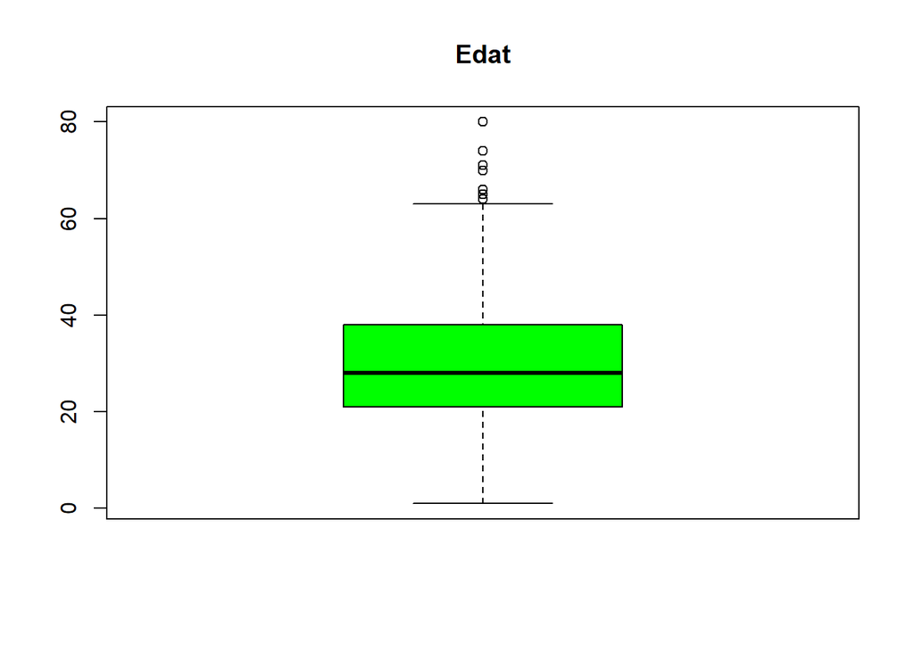

```r
# Veiem els valors extrems
totalData.bp.edat <- boxplot(totalData$Age, main="Edat", col="green")
```

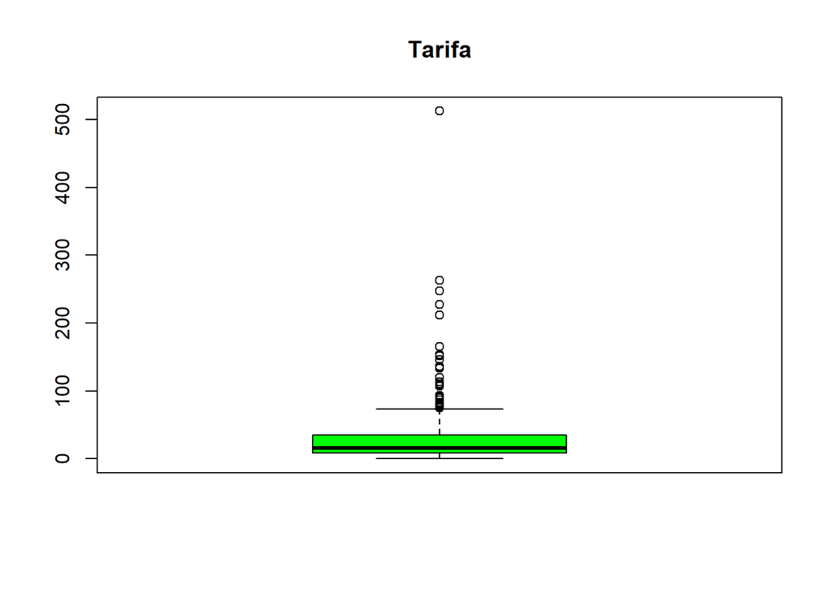

```r
totalData.bp.tarifa <- boxplot(totalData$Fare, main="Tarifa", col="green")
```

```r
totalData.bp.edat$out
```

```
##  [1] 66 65 71 65 64 65 71 64 80 70 70 74
```

```r
totalData.bp.tarifa$out
```

```
##  [1] 263.0000  82.1708  76.7292  80.0000  83.4750 263.0000  77.2875 247.5208
##  [9]  77.2875  79.2000 146.5208 113.2750  76.2917  90.0000  83.4750  90.0000
## [17]  86.5000 512.3292  79.6500 153.4625 135.6333  77.9583  78.8500  91.0792
## [25] 151.5500 247.5208 108.9000  83.1583 262.3750 164.8667 134.5000 135.6333
## [33] 153.4625 134.5000 263.0000  75.2500 135.6333 211.5000 227.5250 120.0000
## [41] 113.2750  90.0000 120.0000 263.0000  81.8583  89.1042  91.0792  90.0000
## [49]  78.2667 151.5500  86.5000 108.9000  93.5000 106.4250 106.4250 110.8833
## [57]  79.6500 110.8833  79.6500  79.2000  78.2667 153.4625  77.9583  76.7292
## [65] 113.2750 133.6500 512.3292  76.7292 211.3375 110.8833 227.5250 151.5500
## [73] 227.5250 211.3375 512.3292  78.8500 262.3750  86.5000 120.0000  77.9583
## [81] 211.3375  79.2000 120.0000  93.5000  80.0000  83.1583 164.8667  83.1583
```

Discretitzem quan té sentit i en funció de les capacitats de cada variable.

```r
# Afegim dos camps nous a les dades. Aquests valors són l'edat i la tarifa discretitzada

# Discretitzem
totalData["Segment_edat"] <- cut(totalData$Age, breaks = c(0,10,20,30,40,50,60,70,100), labels = c("0-10", "10-20", "20-30", "30-40","40-50","50-60","60-70","70-79"))
totalData["Segment_tarifa"] <- cut(totalData$Fare, breaks = c(0,7,10,15,30,50,200,600), labels = c("0-7", "7-10", "10-15","15-30","30-50","50-200","200-600"))
totalData["Segment_majors_menors"] <- cut(totalData$Age, breaks = c(0,18,100), labels = c("Menor d'edat", "Major d'edat"))
```

Hem fet les discretitzacions anteriors per comprovar si hi ha alguna relació de supervivència en funció de l’edat, el preu pagat i una més general que seria si són majors o menors d’edat. A més a més analitzarem el sexe també.

```r
# Observem les dades discretitzades
head(totalData)
```

```
##   PassengerId Survived Pclass
## 1           1        0      3
## 2           2        1      1
## 3           3        1      3
## 4           4        1      1
## 5           5        0      3
## 7           7        0      1
##                                                  Name    Sex Age SibSp Parch
## 1                             Braund, Mr. Owen Harris   male  22     1     0
## 2 Cumings, Mrs. John Bradley (Florence Briggs Thayer) female  38     1     0
## 3                              Heikkinen, Miss. Laina female  26     0     0
## 4        Futrelle, Mrs. Jacques Heath (Lily May Peel) female  35     1     0
## 5                            Allen, Mr. William Henry   male  35     0     0
## 7                             McCarthy, Mr. Timothy J   male  54     0     0
##             Ticket    Fare Cabin Embarked Segment_edat Segment_tarifa
## 1        A/5 21171  7.2500              S        20-30           7-10
## 2         PC 17599 71.2833   C85        C        30-40         50-200
## 3 STON/O2. 3101282  7.9250              S        20-30           7-10
## 4           113803 53.1000  C123        S        30-40         50-200
## 5           373450  8.0500              S        30-40           7-10
## 7            17463 51.8625   E46        S        50-60         50-200
##   Segment_majors_menors
## 1          Major d'edat
## 2          Major d'edat
## 3          Major d'edat
## 4          Major d'edat
## 5          Major d'edat
## 7          Major d'edat
```

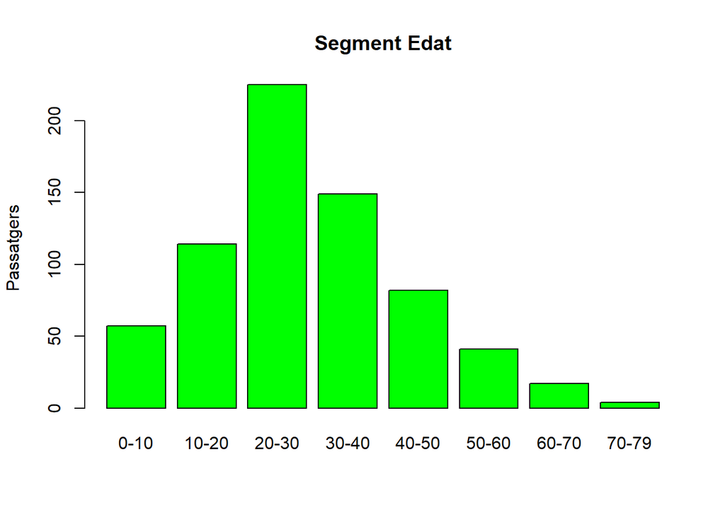

```r
# Primeres visualitzacions
plot(totalData$Segment_edat, main='Segment Edat', ylab='Passatgers', col='green')
```

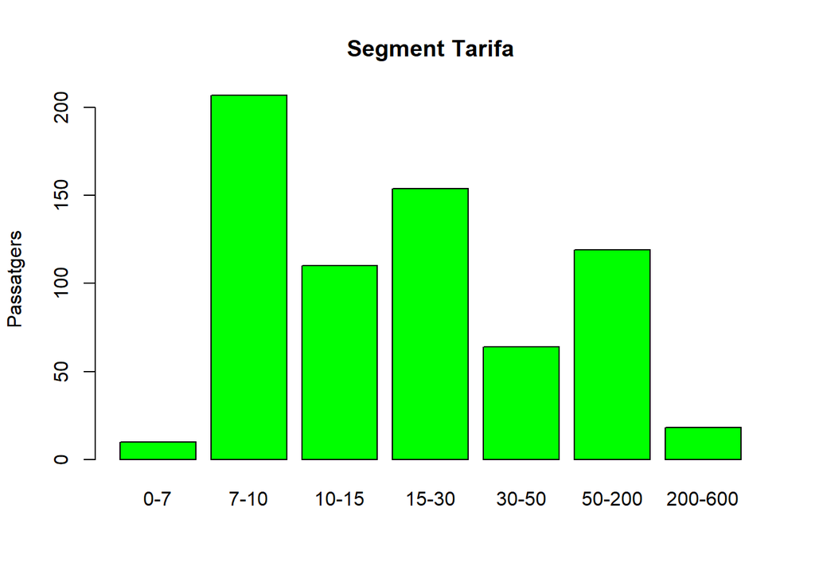

```r
plot(totalData$Segment_tarifa, main='Segment Tarifa', ylab='Passatgers', col='green')
```

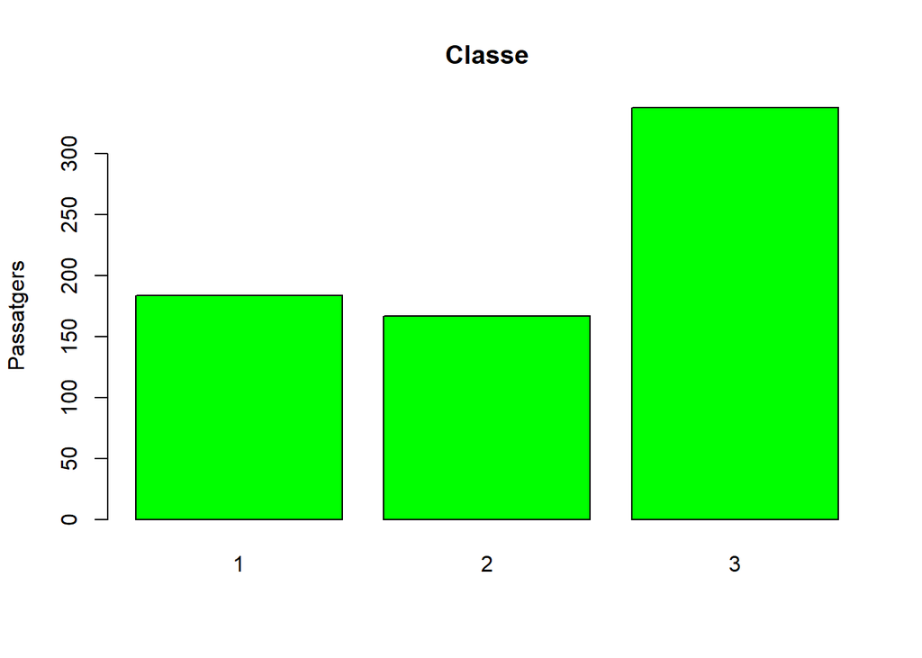

```r
plot(totalData$Pclass, main='Classe', ylab='Passatgers', col='green')
```

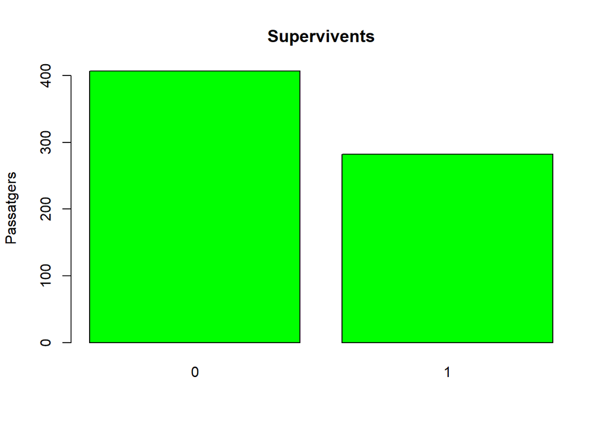

```r
plot(totalData$Survived, main='Supervivents', ylab='Passatgers', col='green')
```

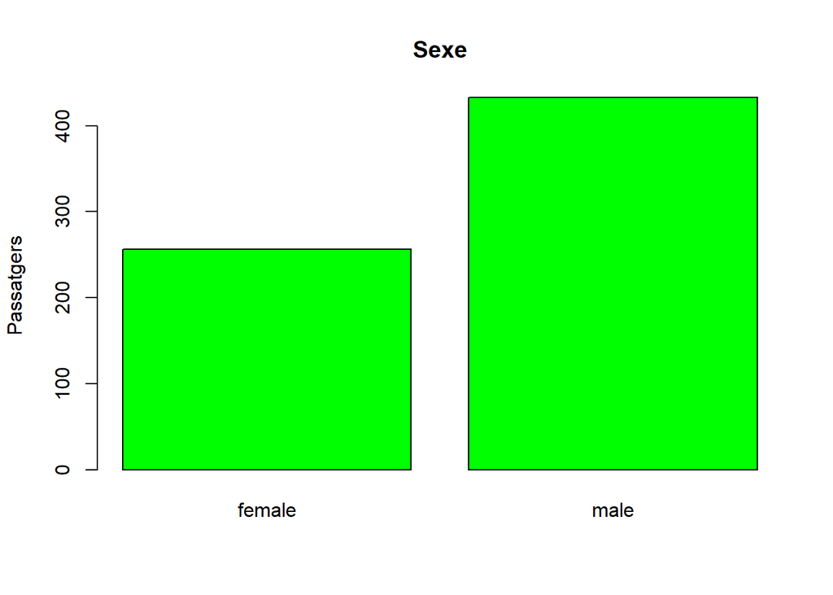

```r
plot(totalData$Sex, main='Sexe', ylab='Passatgers', col='green')
```

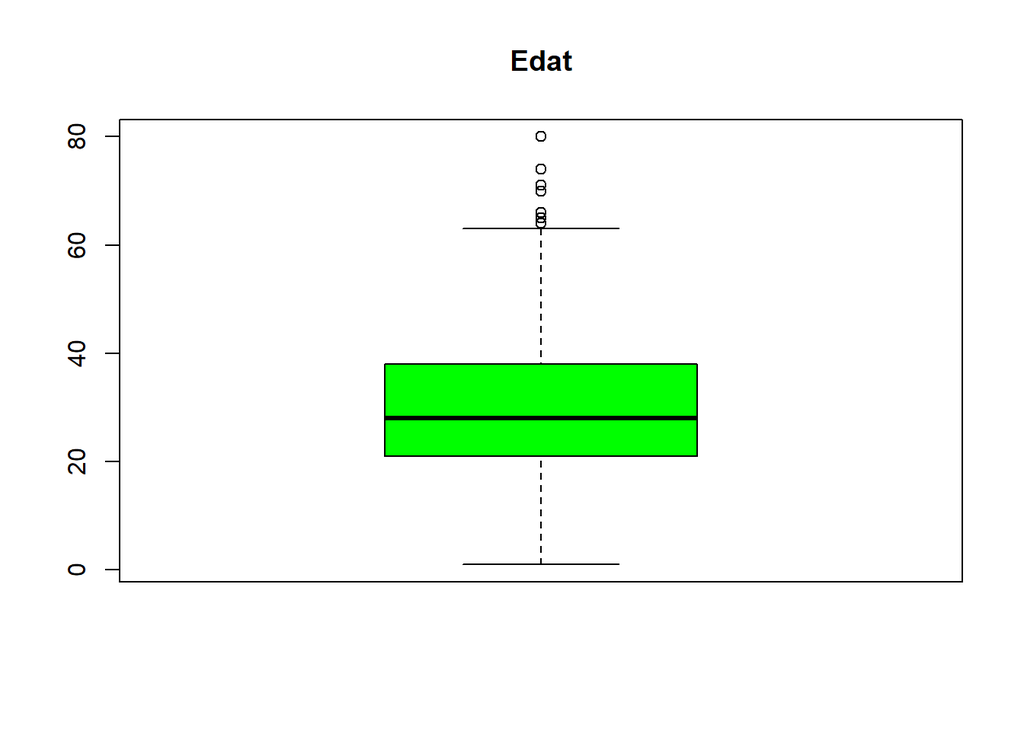

```r
boxplot(totalData$Age, main='Edat', col='green')
```

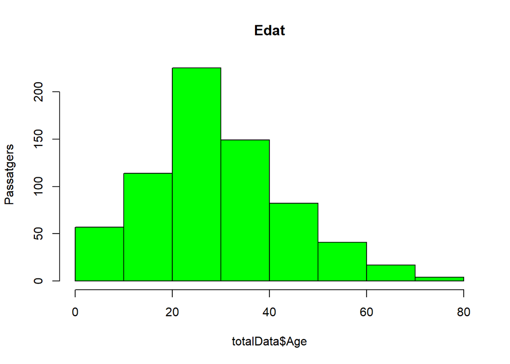

```r
hist(totalData$Age, main='Edat', ylab='Passatgers', col='green')
```

# 4 Anàlisi de les dades i Representació dels resultats

## 4.1 Selecció dels grups de dades que es volen analitzar

Seleccionem la meitat dels atributs, els que veiem que poden ser susceptibles d’anàlisi:

```r
totalData = totalData [ , c(2,3,5,6,10,13,14,15)]
```

## 4.2 Comprovació de la normalitat i homogeneïtat de la variància

Comprovem la normalitat de les dades amb el test de Kolmogorov-Smirnov i de Shapiro-Wilk:

```r
# canviem el tipus de dades a numèric

totalData$Survived=as.numeric(totalData$Survived)
totalData$Pclass=as.numeric(totalData$Pclass)

ks.test(totalData$Age, pnorm, mean(totalData$Age), sd(totalData$Age))
```

```
##
##  One-sample Kolmogorov-Smirnov test
##
## data:  totalData$Age
## D = 0.0705, p-value = 0.002121
## alternative hypothesis: two-sided
```

```r
ks.test(totalData$Fare, pnorm, mean(totalData$Fare), sd(totalData$Fare))
```

```
##
##  One-sample Kolmogorov-Smirnov test
##
## data:  totalData$Fare
## D = 0.28085, p-value < 2.2e-16
## alternative hypothesis: two-sided
```

```r
ks.test(totalData$Pclass, pnorm, mean(totalData$Pclass), sd(totalData$Pclass))
```

```
##
##  One-sample Kolmogorov-Smirnov test
##
## data:  totalData$Pclass
## D = 0.3124, p-value < 2.2e-16
## alternative hypothesis: two-sided
```

```r
ks.test(totalData$Survived, pnorm, mean(totalData$Survived), sd(totalData$Survived))
```

```
##
##  One-sample Kolmogorov-Smirnov test
##
## data:  totalData$Survived
## D = 0.38795, p-value < 2.2e-16
## alternative hypothesis: two-sided
```

```r
shapiro.test(totalData$Age)
```

```
##
##  Shapiro-Wilk normality test
##
## data:  totalData$Age
## W = 0.98027, p-value = 5.151e-08
```

```r
shapiro.test(totalData$Fare)
```

```
##
##  Shapiro-Wilk normality test
##
## data:  totalData$Fare
## W = 0.53161, p-value < 2.2e-16
```

```r
shapiro.test(totalData$Pclass)
```

```
##
##  Shapiro-Wilk normality test
##
## data:  totalData$Pclass
## W = 0.74813, p-value < 2.2e-16
```

```r
shapiro.test(totalData$Survived)
```

```
##
##  Shapiro-Wilk normality test
##
## data:  totalData$Survived
## W = 0.62449, p-value < 2.2e-16
```

On veiem que ambdós tests rebutgen la normalitat de les dades perquè el p-value és inferior a 0.05.

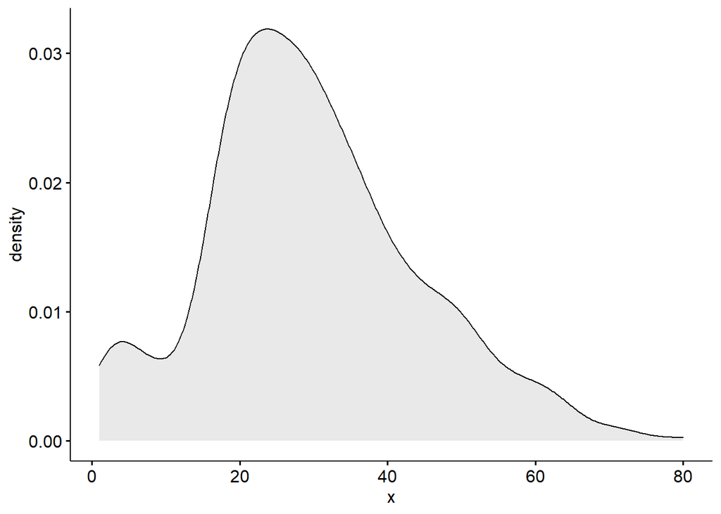

```r
# Observem visualment la normalitat i distribució de les variables

# Density plot i QQ plot
ggdensity(totalData$Age, fill = "lightgray")
```

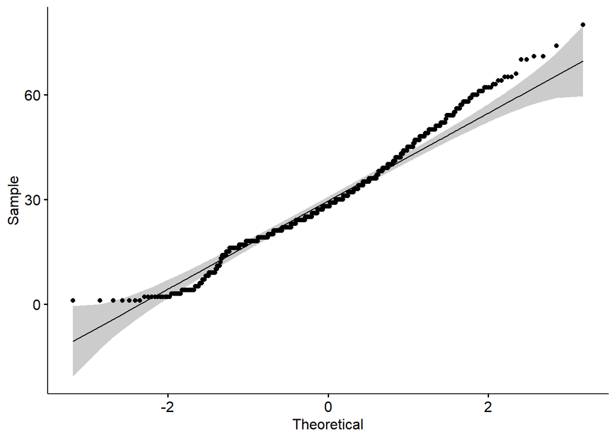

```r
ggqqplot(totalData$Age)
```

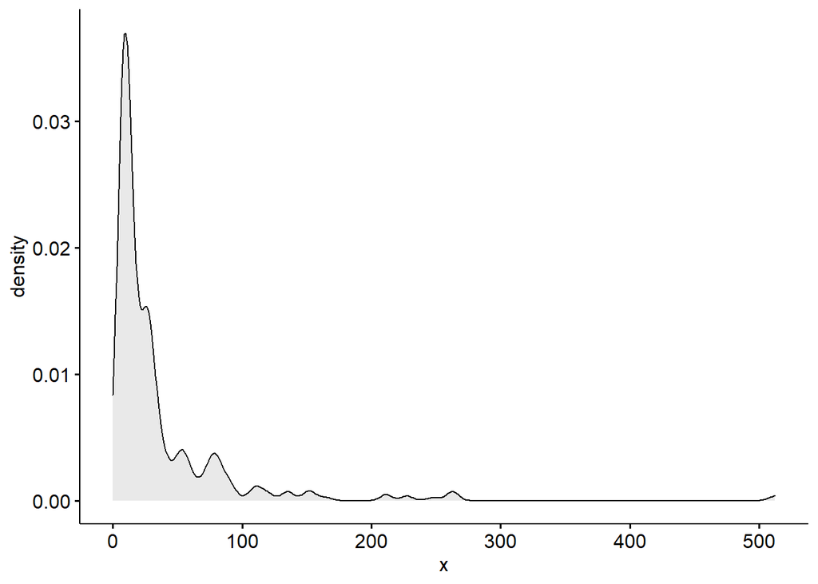

```r
ggdensity(totalData$Fare, fill = "lightgray")
```

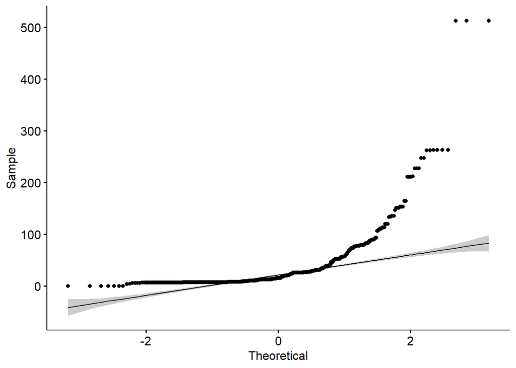

```r
ggqqplot(totalData$Fare)
```

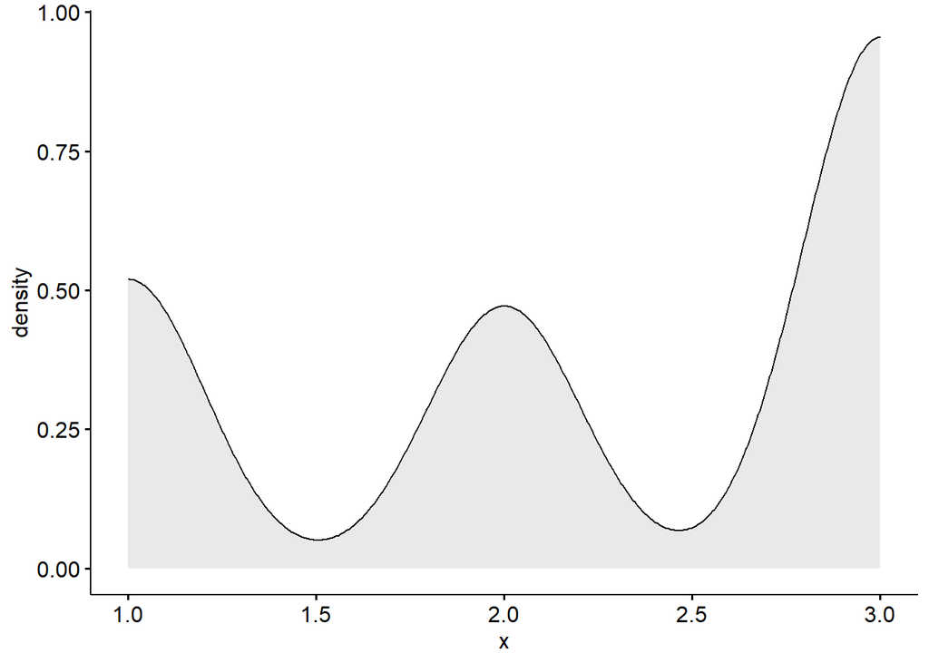

```r
ggdensity(totalData$Pclass, fill = "lightgray")
```

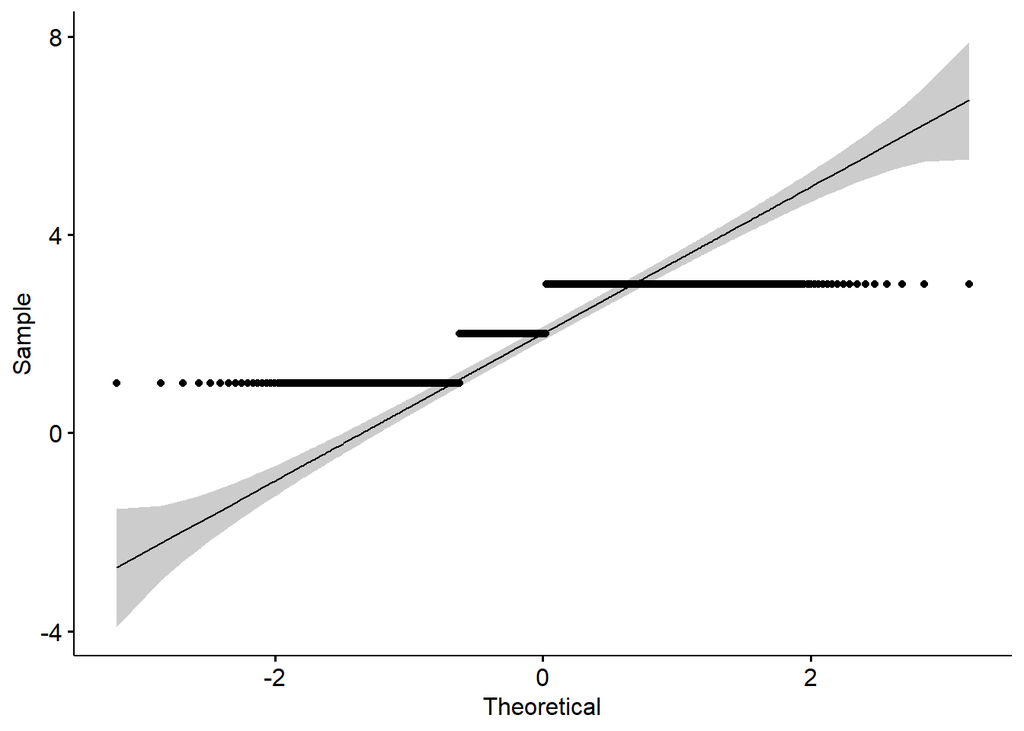

```r
ggqqplot(totalData$Pclass)
```

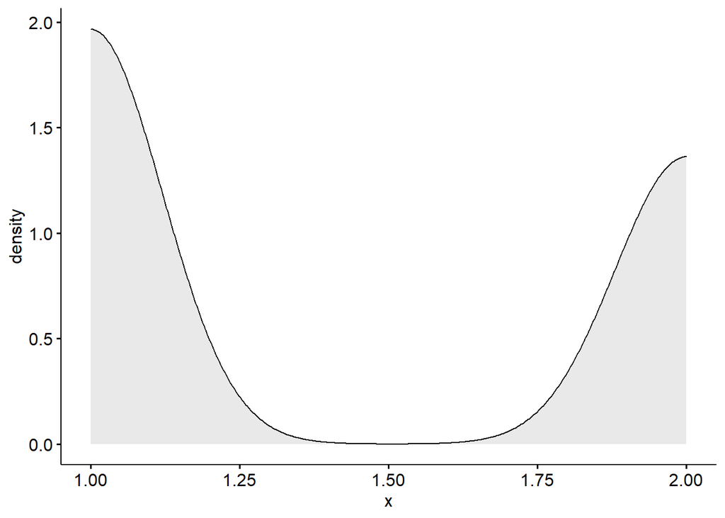

```r
ggdensity(totalData$Survived, fill = "lightgray")
```

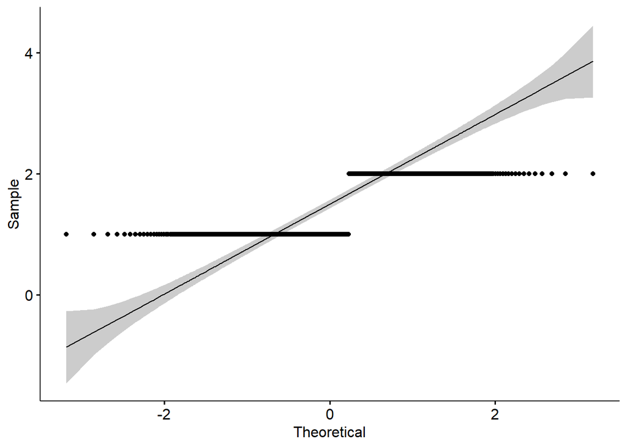

```r
ggqqplot(totalData$Survived)
```

Comprovem la homogeneïtat de la variància amb el test de Fligner-Killeen per a dades que no compleixen la condició de normalitat:

```r
fligner.test(totalData$Age, totalData$Survived)
```

```
##
##  Fligner-Killeen test of homogeneity of variances
##
## data:  totalData$Age and totalData$Survived
## Fligner-Killeen:med chi-squared = 0.28528, df = 1, p-value = 0.5933
```

```r
fligner.test(totalData$Fare, totalData$Survived)
```

```
##
##  Fligner-Killeen test of homogeneity of variances
##
## data:  totalData$Fare and totalData$Survived
## Fligner-Killeen:med chi-squared = 66.827, df = 1, p-value = 2.965e-16
```

```r
fligner.test(as.numeric(totalData$Pclass), totalData$Survived)
```

```
##
##  Fligner-Killeen test of homogeneity of variances
##
## data:  as.numeric(totalData$Pclass) and totalData$Survived
## Fligner-Killeen:med chi-squared = 6.505, df = 1, p-value = 0.01076
```

## 4.3 Aplicació de proves estadístiques per comparar grups de dades

Fem la Regressió linial per aproximar la relació de dependència linial entre Survived i la resta de variables:

```r
# Survived amb Age
m1 = lm(Survived~Age,data=totalData)
summary(m1)
```

```
##
## Call:
## lm(formula = Survived ~ Age, data = totalData)
##
## Residuals:
##     Min      1Q  Median      3Q     Max
## -0.4574 -0.4174 -0.3840  0.5810  0.6743
##
## Coefficients:
##              Estimate Std. Error t value Pr(>|t|)
## (Intercept)  1.459027   0.043349  33.658   <2e-16 ***
## Age         -0.001666   0.001310  -1.272    0.204
## ---
## Signif. codes:  0 '***' 0.001 '**' 0.01 '*' 0.05 '.' 0.1 ' ' 1
##
## Residual standard error: 0.4918 on 687 degrees of freedom
## Multiple R-squared:  0.002351,   Adjusted R-squared:  0.0008989
## F-statistic: 1.619 on 1 and 687 DF,  p-value: 0.2037
```

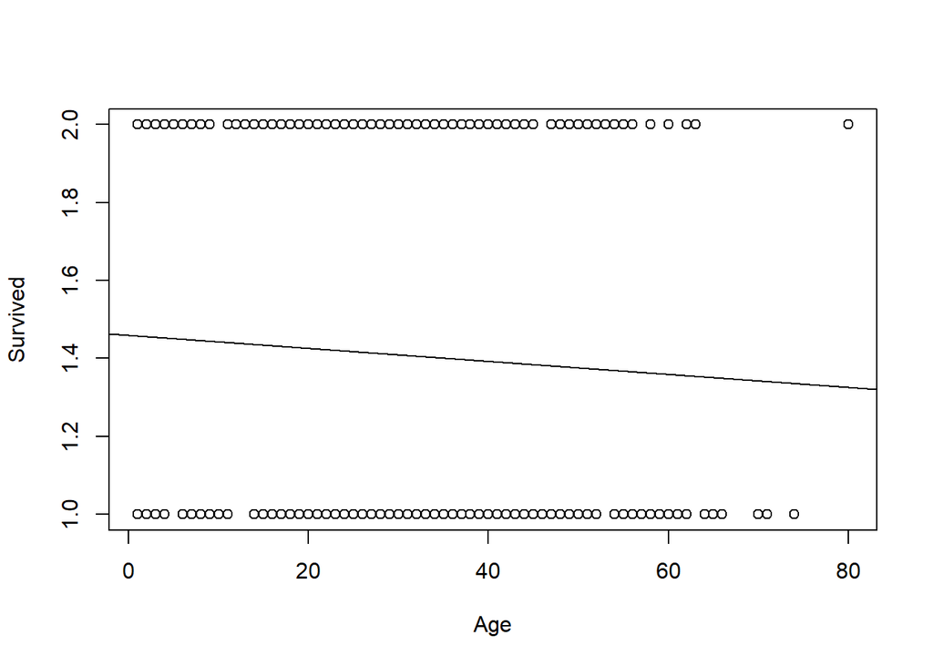

```r
plot(totalData$Age, totalData$Survived, xlab='Age', ylab='Survived')
abline(m1)
```

Segons el R-squared veiem com la supervivència i l’edat es correlacionen molt poc, amb un 0,002351.

```r
# Survived amb Fare
m2 = lm(Survived~Fare,data=totalData)
summary(m2)
```

```
##
## Call:
## lm(formula = Survived ~ Fare, data = totalData)
##
## Residuals:
##     Min      1Q  Median      3Q     Max
## -0.9663 -0.3583 -0.3421  0.5901  0.6769
##
## Coefficients:
##              Estimate Std. Error t value Pr(>|t|)
## (Intercept) 1.3230804  0.0216571  61.092  < 2e-16 ***
## Fare        0.0024458  0.0003381   7.234 1.26e-12 ***
## ---
## Signif. codes:  0 '***' 0.001 '**' 0.01 '*' 0.05 '.' 0.1 ' ' 1
##
## Residual standard error: 0.4747 on 687 degrees of freedom
## Multiple R-squared:  0.07078,    Adjusted R-squared:  0.06943
## F-statistic: 52.33 on 1 and 687 DF,  p-value: 1.256e-12
```

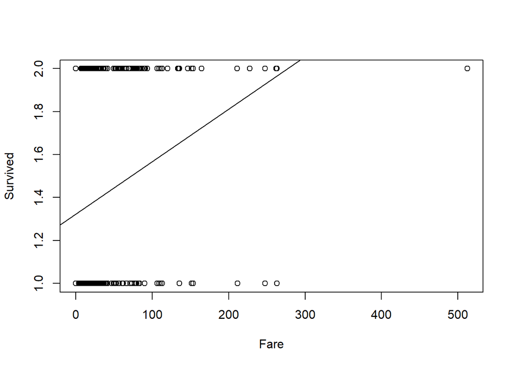

```r
plot(totalData$Fare, totalData$Survived, xlab='Fare', ylab='Survived')
abline(m2)
```

Segons el R-squared veiem com la supervivència i el preu pagat es correlacionen bastant més que l’edat, amb un 0,07078.

```r
# Survived amb Pclass
m3 = lm(Survived~Pclass,data=totalData)
summary(m3)
```

```
##
## Call:
## lm(formula = Survived ~ Pclass, data = totalData)
##
## Residuals:
##     Min      1Q  Median      3Q     Max
## -0.6653 -0.2468 -0.2468  0.3347  0.7532
##
## Coefficients:
##             Estimate Std. Error t value Pr(>|t|)
## (Intercept)  1.87458    0.04950   37.87   <2e-16 ***
## Pclass      -0.20926    0.02082  -10.05   <2e-16 ***
## ---
## Signif. codes:  0 '***' 0.001 '**' 0.01 '*' 0.05 '.' 0.1 ' ' 1
##
## Residual standard error: 0.4598 on 687 degrees of freedom
## Multiple R-squared:  0.1282, Adjusted R-squared:  0.1269
## F-statistic:   101 on 1 and 687 DF,  p-value: < 2.2e-16
```

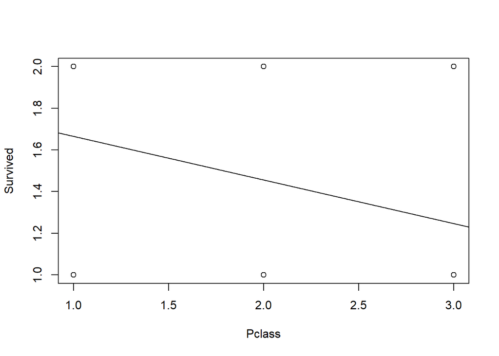

```r
plot(totalData$Pclass, totalData$Survived, xlab='Pclass', ylab='Survived')
abline(m3)
```

```r
# Survived amb Pclass+Fare
m4 = lm(Survived~Pclass+Fare,data=totalData)
summary(m4)
```

```
##
## Call:
## lm(formula = Survived ~ Pclass + Fare, data = totalData)
##
## Residuals:
##     Min      1Q  Median      3Q     Max
## -0.8331 -0.2679 -0.2466  0.3815  0.7605
##
## Coefficients:
##               Estimate Std. Error t value Pr(>|t|)
## (Intercept)  1.7718893  0.0662978  26.726  < 2e-16 ***
## Pclass      -0.1774597  0.0248761  -7.134 2.49e-12 ***
## Fare         0.0009074  0.0003912   2.319   0.0207 *
## ---
## Signif. codes:  0 '***' 0.001 '**' 0.01 '*' 0.05 '.' 0.1 ' ' 1
##
## Residual standard error: 0.4583 on 686 degrees of freedom
## Multiple R-squared:  0.135,  Adjusted R-squared:  0.1324
## F-statistic: 53.51 on 2 and 686 DF,  p-value: < 2.2e-16
```

```r
# Survived amb Pclass (manera quadràtica)
m5 = lm(Survived~Pclass+I(Pclass^2),data=totalData)
summary(m5)
```

```
##
## Call:
## lm(formula = Survived ~ Pclass + I(Pclass^2), data = totalData)
##
## Residuals:
##     Min      1Q  Median      3Q     Max
## -0.6576 -0.2426 -0.2426  0.3424  0.7574
##
## Coefficients:
##             Estimate Std. Error t value Pr(>|t|)
## (Intercept)  1.79627    0.14960  12.007   <2e-16 ***
## Pclass      -0.11571    0.16991  -0.681    0.496
## I(Pclass^2) -0.02295    0.04137  -0.555    0.579
## ---
## Signif. codes:  0 '***' 0.001 '**' 0.01 '*' 0.05 '.' 0.1 ' ' 1
##
## Residual standard error: 0.46 on 686 degrees of freedom
## Multiple R-squared:  0.1286, Adjusted R-squared:  0.126
## F-statistic:  50.6 on 2 and 686 DF,  p-value: < 2.2e-16
```

```r
# Tornem a deixar com a factors les dades
totalData$Survived=as.factor(totalData$Survived-1) # restem 1 per tornar les variables supervivència a (0,1)
totalData$Pclass=as.factor(totalData$Pclass)
```

```r
# prediccions amb la variable supervivència

# regressió logística

rl=glm(formula = Survived~Pclass+Age+Sex,data = totalData, family=binomial(link = logit))
summary(rl)
```

```
##
## Call:
## glm(formula = Survived ~ Pclass + Age + Sex, family = binomial(link = logit),
##     data = totalData)
##
## Deviance Residuals:
##     Min       1Q   Median       3Q      Max
## -2.6595  -0.6799  -0.4065   0.6406   2.4143
##
## Coefficients:
##              Estimate Std. Error z value Pr(>|z|)
## (Intercept)  3.569584   0.405032   8.813  < 2e-16 ***
## Pclass2     -1.307829   0.280920  -4.656 3.23e-06 ***
## Pclass3     -2.475164   0.283103  -8.743  < 2e-16 ***
## Age         -0.031289   0.007841  -3.991 6.59e-05 ***
## Sexmale     -2.545023   0.209846 -12.128  < 2e-16 ***
## ---
## Signif. codes:  0 '***' 0.001 '**' 0.01 '*' 0.05 '.' 0.1 ' ' 1
##
## (Dispersion parameter for binomial family taken to be 1)
##
##     Null deviance: 932.35  on 688  degrees of freedom
## Residual deviance: 629.71  on 684  degrees of freedom
## AIC: 639.71
##
## Number of Fisher Scoring iterations: 4
```

```r
exp(confint(rl))
```

```
##                   2.5 %     97.5 %
## (Intercept) 16.42761419 80.5521595
## Pclass2      0.15455067  0.4656264
## Pclass3      0.04763359  0.1447757
## Age          0.95415030  0.9839832
## Sexmale      0.05151056  0.1174022
```

Interpretació L’odds ratio ens indica l’augment o disminució de probabilitat de supervivència en funció de les variables predictives. Tots els regressors que apareixen tenen valors inferiors a la unitat, això vol dir que la seva presència disminueix la probabilitat de supervivència. Es llegeix de la següent manera: amb un interval de confiança del 95%, ser de la segona classe fa que la probabilitat de sobreviure augmenti de 0,15 a 0,46 vegades. És a dir, la probabilitat de morir és de 1/0,15 a 1/0,46, o sigui del 2,17% al 6,67%. En el cas de ser de tercera classe la probabilitat de no sobreviure era del 6,94% al 21,27% i si eres home la probabilitat pujava del 8,52% al 19,41%. L’edat, tot i ser estadísticament significativa, no afecta massa a la probabilitat, ser un any més gran disminueix la probabilitat de sobreviure del 1,01% al 1,04%.

```r
# fem prediccions del model

prediccio1=predict(rl, newdata =  data.frame(Pclass='3',Age=40,Sex='male'),type ="response")
prediccio2=predict(rl, newdata =  data.frame(Pclass='1',Age=5,Sex='female'),type ="response")
print(prediccio1)
```

```
##          1
## 0.06284481
```

```r
print(prediccio2)
```

```
##         1
## 0.9681126
```

La predicció de supervivència per un home de 40 anys de la tercera classe era del 6%. En canvi, una nena de 5 anys de primera classe tenia una probabilitat de sobreviure del 96%

```r
# matriu de confusió del model

confusionMatrix(table(predict(rl,type = "response")>=0.5,totalData$Survived=="1"))
```

```
## Confusion Matrix and Statistics
##
##
##         FALSE TRUE
##   FALSE   342   78
##   TRUE     65  204
##
##                Accuracy : 0.7925
##                  95% CI : (0.7602, 0.8222)
##     No Information Rate : 0.5907
##     P-Value [Acc > NIR] : <2e-16
##
##                   Kappa : 0.5677
##
##  Mcnemar's Test P-Value : 0.3156
##
##             Sensitivity : 0.8403
##             Specificity : 0.7234
##          Pos Pred Value : 0.8143
##          Neg Pred Value : 0.7584
##              Prevalence : 0.5907
##          Detection Rate : 0.4964
##    Detection Prevalence : 0.6096
##       Balanced Accuracy : 0.7818
##
##        'Positive' Class : FALSE
##
```

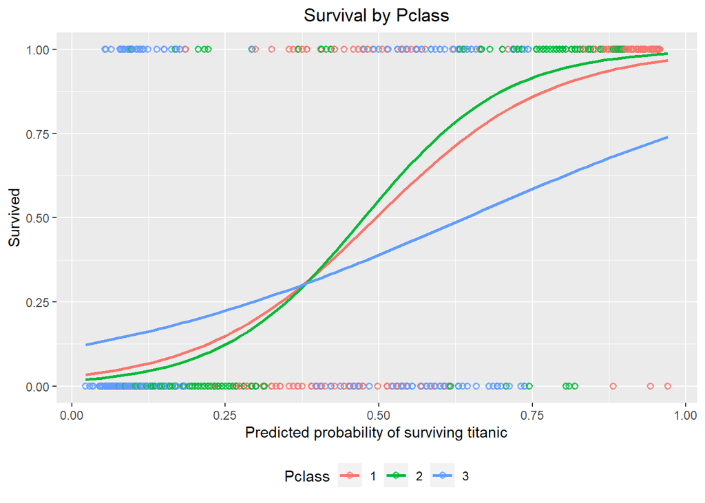

```r
# visualització de la regressió logística

predicted.data <- data.frame(probability.of.survival = rl$fitted.value, Survived = as.numeric(totalData$Survived)-1, Pclass = totalData$Pclass)
predicted.data <- predicted.data[order(predicted.data$probability.of.survival, decreasing = FALSE),]
ggplot(data=predicted.data,aes(x=probability.of.survival,y=Survived,col=Pclass))+
  geom_point(alpha=0.8,shape=1,stroke=1)+
  xlab('Predicted probability of surviving titanic')+
  ylab('Survived')+
  stat_smooth(method="glm", method.args=list(family="binomial"), se=FALSE,fullrange = TRUE)+
  theme(legend.position = 'bottom',plot.title = element_text(hjust = 0.5))+
  ggtitle('Survival by Pclass')
```

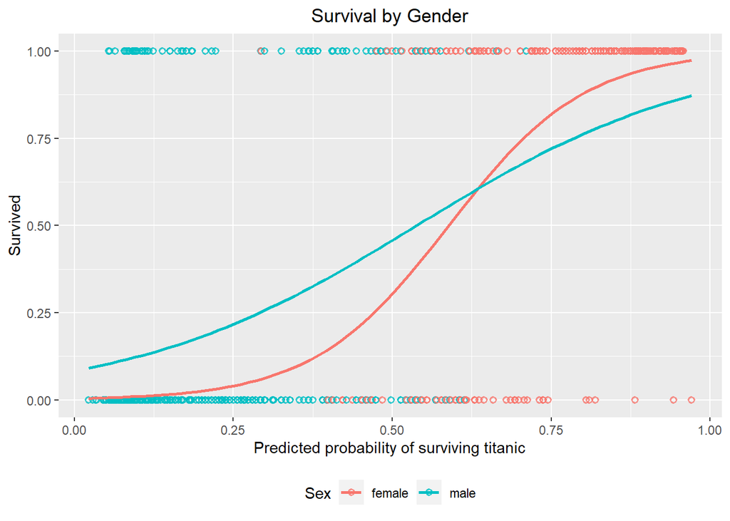

```r
predicted.data <- data.frame(probability.of.survival = rl$fitted.value, Survived = as.numeric(totalData$Survived)-1, Sex=totalData$Sex)
predicted.data <- predicted.data[order(predicted.data$probability.of.survival, decreasing = FALSE),]
ggplot(data=predicted.data,aes(x=probability.of.survival,y=Survived,col=Sex))+
  geom_point(alpha=0.8,shape=1,stroke=1)+
  xlab('Predicted probability of surviving titanic')+
  ylab('Survived')+
  stat_smooth(method="glm", method.args=list(family="binomial"), se=FALSE,fullrange = TRUE)+
  theme(legend.position = 'bottom',plot.title = element_text(hjust = 0.5))+
  ggtitle('Survival by Gender')
```

# 5 Representació dels resultats

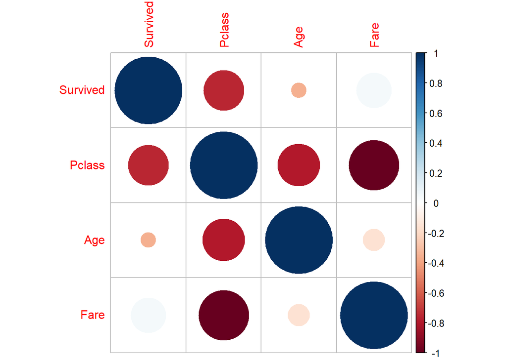

```r
# Mirem la correlació entre variables (tots els camps han de ser numèrics)
totalData$Survived=as.numeric(totalData$Survived)
totalData$Pclass=as.numeric(totalData$Pclass)
titanic.data<-data.frame(totalData[,c(1,2,4,5)])

corr.titanic.data<-cor(titanic.data)
corrplot(corr.titanic.data,method="circle")
```

```r
# Tornem a deixar els atributs com a factors
totalData$Survived=as.factor(totalData$Survived-1) # restem 1 per tornar les variables supervivència a (0,1)
totalData$Pclass=as.factor(totalData$Pclass)
```

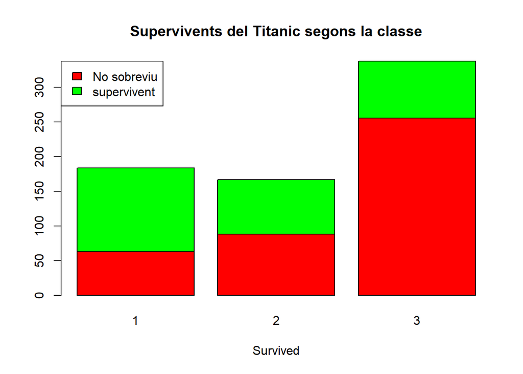

```r
titanic.data<-table(totalData[,c(1,2)])
barplot(titanic.data, main = "Supervivents del Titanic segons la classe", xlab = "Survived", col = c("red", "green"))
legend("topleft", c("No sobreviu", "supervivent"), fill = c("red", "green"))
```

Al gràfic anterior veiem com la classe té molt a veure en la supervivència de les persones que anaven al titànic.

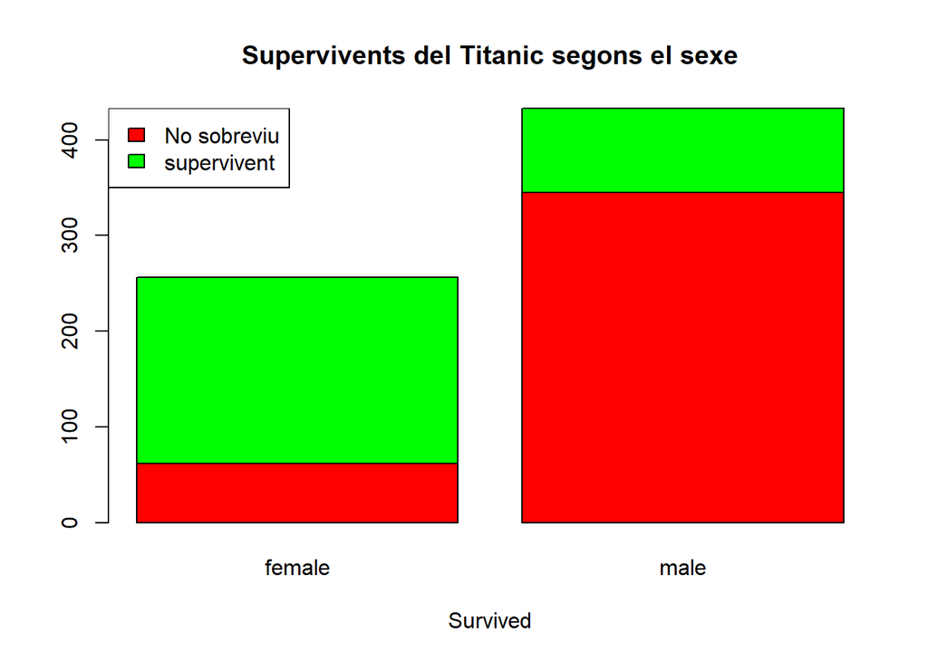

```r
titanic.data<-table(totalData[,c(1,3)])
barplot(titanic.data, main = "Supervivents del Titanic segons el sexe", xlab = "Survived", col = c("red", "green"))
legend("topleft", c("No sobreviu", "supervivent"), fill = c("red", "green"))
```

El sexe també va ser determinant

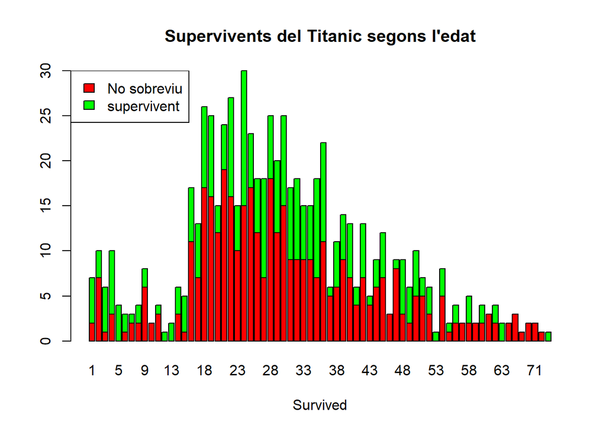

```r
titanic.data<-table(totalData[,c(1,4)])
barplot(titanic.data, main = "Supervivents del Titanic segons l'edat", xlab = "Survived", col = c("red", "green"))
legend("topleft", c("No sobreviu", "supervivent"), fill = c("red", "green"))
```

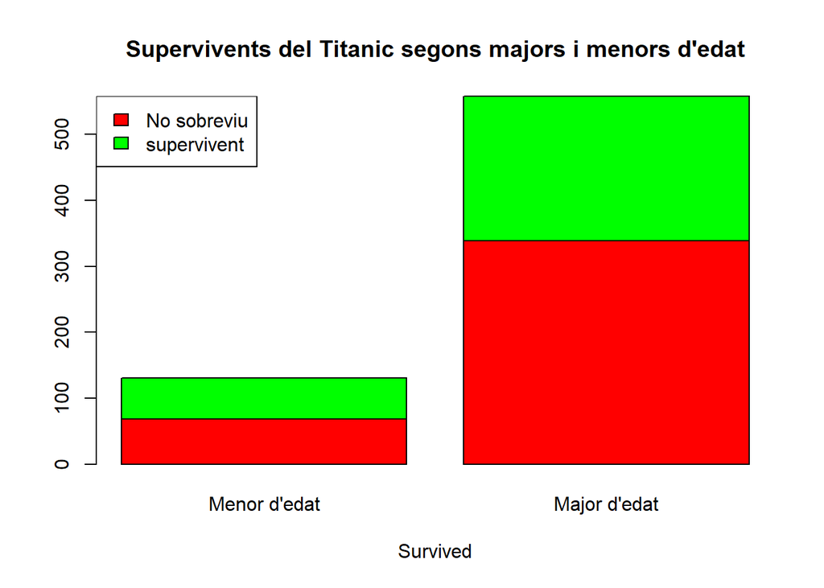

```r
titanic.data<-table(totalData[,c(1,8)])
barplot(titanic.data, main = "Supervivents del Titanic segons majors i menors d'edat", xlab = "Survived", col = c("red", "green"))
legend("topleft", c("No sobreviu", "supervivent"), fill = c("red", "green"))
```

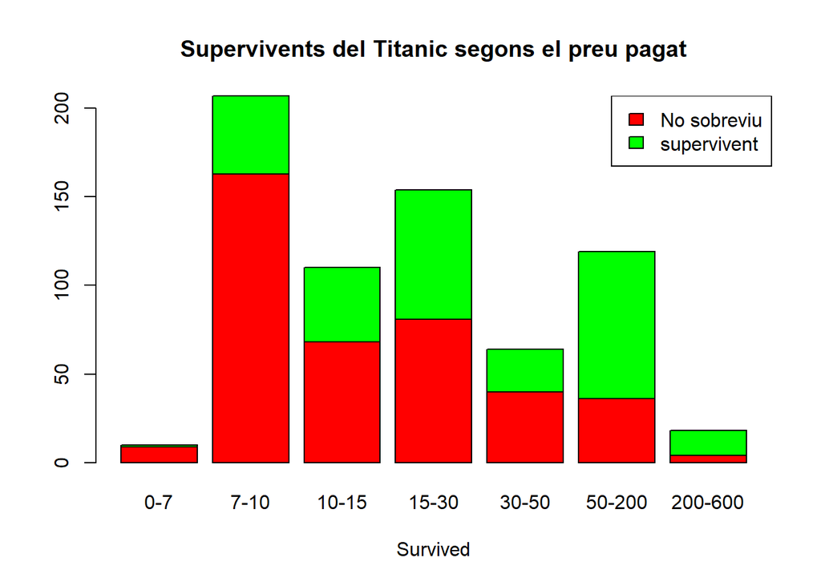

```r
titanic.data<-table(totalData[,c(1,7)])
barplot(titanic.data, main = "Supervivents del Titanic segons el preu pagat", xlab = "Survived", col = c("red", "green"))
legend("topright", c("No sobreviu", "supervivent"), fill = c("red", "green"))
```

## 5.1 Arbre de decisió

Crearem un arbre de decisió que permeti analitzar quines persones sobreviuran segons l’anàlisi efectuat anteriorment. Per tant, la variable per la qual classificarem és el camp Survived.

Ens interessarà desordenar el dataset per si tingués algun ordre i guardarem les dades amb el nou nom com “data_random”.

```r
set.seed(1)
data_random <- totalData[sample(nrow(totalData)),]
```

Per a la futura avaluació de l’arbre de decisió, és necessari dividir el conjunt de dades en un conjunt d’entrenament i un conjunt de prova. El conjunt d’entrenament és el subconjunt del conjunt original de dades utilitzat per a construir un primer model; i el conjunt de prova, el subconjunt del conjunt original de dades utilitzat per a avaluar la qualitat del model.

El més correcte serà utilitzar un conjunt de dades diferent del que utilitzem per a construir l’arbre, és a dir, un conjunt diferent del d’entrenament. No hi ha cap proporció fixada respecte al nombre relatiu de components de cada subconjunt, però la més utilitzada acostuma a ser 2/3 per al conjunt d’entrenament i 1/3, per al conjunt de prova.

La variable per la qual classificarem és el camp Survived, que està a la primera columna.

```r
set.seed(666)
y <- data_random[,1]
X <- data_random[,2:8]
```

Podem triar el subconjunt d’entrenament i el de prova creant un rang:

```r
set.seed(555)
indexes = sample(1:nrow(totalData), size=floor((2/3)*nrow(totalData)))
trainX <- X[indexes,]
trainy <- y[indexes]
testX  <- X[-indexes,]
testy  <- y[-indexes]
```

Després d’una extracció aleatòria de casos és altament recomanable efectuar una anàlisi de dades mínim per a assegurar-nos de no obtenir classificadors esbiaixats pels valors que conté cada mostra.

```r
summary(trainX)
```

```
##  Pclass      Sex           Age             Fare         Segment_edat
##  1:125   female:159   Min.   : 1.00   Min.   :  0.00   20-30  :147
##  2:109   male  :300   1st Qu.:20.00   1st Qu.:  8.05   30-40  :102
##  3:225                Median :28.00   Median : 15.85   10-20  : 78
##                       Mean   :29.76   Mean   : 32.63   40-50  : 52
##                       3rd Qu.:38.00   3rd Qu.: 34.38   0-10   : 39
##                       Max.   :80.00   Max.   :263.00   50-60  : 26
##                                                        (Other): 15
##  Segment_tarifa  Segment_majors_menors
##  7-10   :138    Menor d'edat: 89
##  15-30  :107    Major d'edat:370
##  50-200 : 80
##  10-15  : 69
##  30-50  : 40
##  (Other): 18
##  NA's   :  7
```

```r
summary(trainy)
```

```
##   0   1
## 274 185
```

```r
summary(testX)
```

```
##  Pclass      Sex           Age             Fare          Segment_edat
##  1: 59   female: 97   Min.   : 2.00   Min.   :  6.450   20-30  :78
##  2: 58   male  :133   1st Qu.:21.00   1st Qu.:  8.373   30-40  :47
##  3:113                Median :28.00   Median : 15.950   10-20  :36
##                       Mean   :30.03   Mean   : 40.471   40-50  :30
##                       3rd Qu.:39.00   3rd Qu.: 35.219   0-10   :18
##                       Max.   :66.00   Max.   :512.329   50-60  :15
##                                                         (Other): 6
##  Segment_tarifa  Segment_majors_menors
##  0-7    : 2     Menor d'edat: 42
##  7-10   :69     Major d'edat:188
##  10-15  :41
##  15-30  :47
##  30-50  :24
##  50-200 :39
##  200-600: 8
```

```r
summary(testy)
```

```
##   0   1
## 133  97
```

Es crea l’arbre de decisió usant les dades d’entrenament (cal no oblidar que la variable outcome és de tipus factor). Aquest model ens generarà unes regles que ens determinaran les probabilitats de supervivència:

```r
trainy = as.factor(trainy)
model <- C50::C5.0(trainX, trainy, rules=TRUE )
summary(model)
```

```
##
## Call:
## C5.0.default(x = trainX, y = trainy, rules = TRUE)
##
##
## C5.0 [Release 2.07 GPL Edition]      Sun Jun 06 12:34:59 2021
## -------------------------------
##
## Class specified by attribute `outcome'
##
## Read 459 cases (8 attributes) from undefined.data
##
## Rules:
##
## Rule 1: (13, lift 1.6)
##  Pclass = 3
##  Sex = female
##  Fare > 20.575
##  ->  class 0  [0.933]
##
## Rule 2: (10, lift 1.5)
##  Pclass = 3
##  Age > 16
##  Segment_tarifa = 10-15
##  ->  class 0  [0.917]
##
## Rule 3: (166/25, lift 1.4)
##  Pclass = 3
##  Sex = male
##  ->  class 0  [0.845]
##
## Rule 4: (278/51, lift 1.4)
##  Sex = male
##  Age > 10
##  ->  class 0  [0.814]
##
## Rule 5: (8/1, lift 1.3)
##  Segment_tarifa = 0-7
##  ->  class 0  [0.800]
##
```

[output cut: 28 more lines]

```
##    ----  ----
##     255    19    (a): class 0
##      52   133    (b): class 1
##
##
##  Attribute usage:
##
##   98.69% Sex
##   64.92% Age
##   42.48% Pclass
##    3.92% Fare
##    3.92% Segment_tarifa
##
##
## Time: 0.0 secs
```

El model ens ha creat 8 regles per poder crear l’arbre de decisió que mostrem a continuació. Aquestes regles ens dónen el % de probabilitats que el passatger sobrevisqui o no, segons el valor class sigui classificat en 0 o 1.

[figure not shown]

```r
model <- C50::C5.0(trainX, trainy)
plot(model)
```

Una vegada tenim el model, podem comprovar la seva qualitat predient la classe per a les dades de prova que ens hem reservat al principi.

```r
predicted_model <- predict(model, testX, type="class")
print(sprintf("La precisió de l'arbre és de: %.4f %%",100*sum(predicted_model == testy) / length(predicted_model)))
```

```
## [1] "La precisió de l'arbre és de: 80.8696 %"
```

Quan hi ha poques classes, la qualitat de la predicció es pot analitzar mitjançant una matriu de confusió que identifica els tipus d’errors comesos.

```r
mat_conf<-table(testy,Predicted=predicted_model)
mat_conf
```

```
##      Predicted
## testy   0   1
##     0 118  15
##     1  29  68
```

```r
# Guardem les dades en csv com a arxiu final:
write.csv(totalData,"totalDataFinal.csv")
```